# Storm Impact Research - Assignment 2

## Synopsis

To answer the question: which natural events cause the greatest damage to property and health, this project explored storm database from US National Oceanic and Atmospheric Administration, and find out a list of event type of storms and other severe weather evenets result in health and property damages.

## Data Processing

1. Prepare the tool

```r
library(tidyverse)
```

2. To download Storm Data from the site, read and transform. All types of event started recording since 1996, we removed the data before year 1996. And select only the fields that related to the research.

```r
Origin_dir <- getwd()
if(!file.exists('repdata_data_stormdata.csv.bz2')){
  download.file('https://d396qusza40orc.cloudfront.net/repdata%2Fdata%2FStormData.csv.bz2', 'repdata_data_stormdata.csv.bz2')
}

stormDataraw <- read.csv(bzfile('repdata_data_stormdata.csv.bz2'))
stormData <- stormDataraw %>% select(EVTYPE, BGN_DATE, FATALITIES, INJURIES, PROPDMG, PROPDMGEXP, CROPDMG, CROPDMGEXP)  %>%
                          mutate(BGN_YEAR = as.numeric(format(as.Date(BGN_DATE, format = "%m/%d/%Y"), "%Y"))) %>%
                          filter(BGN_YEAR >= 1996)
stormData$EVTYPE <- str_trim(toupper(stormData$EVTYPE))

str(stormData)
```

```
## 'data.frame':    653530 obs. of  9 variables:
##  $ EVTYPE    : chr  "WINTER STORM" "TORNADO" "TSTM WIND" "TSTM WIND" ...
##  $ BGN_DATE  : Factor w/ 16335 levels "1/1/1966 0:00:00",..: 764 69 69 69 69 255 255 285 464 464 ...
##  $ FATALITIES: num  0 0 0 0 0 0 0 0 0 0 ...
##  $ INJURIES  : num  0 0 0 0 0 0 0 0 0 0 ...
##  $ PROPDMG   : num  380 100 3 5 2 0 400 12 8 12 ...
##  $ PROPDMGEXP: Factor w/ 19 levels "","-","?","+",..: 17 17 17 17 17 1 17 17 17 17 ...
##  $ CROPDMG   : num  38 0 0 0 0 0 0 0 0 0 ...
##  $ CROPDMGEXP: Factor w/ 9 levels "","?","0","2",..: 7 1 1 1 1 1 1 1 1 1 ...
##  $ BGN_YEAR  : num  1996 1996 1996 1996 1996 ...
```

3. Notice that the fields PROPDMGEXP and CROPDMGEXP are the exponent values for PROPDMG and CROPDMG, write a fuction to get total value for CROPs and PROPs damage.
   1. B or b = Billion, M or m = Million, K or k = Thousand, H or h = Hundred.
   2. The numbers from one to ten represent multipler of 10 plus single digits, if DMG = 50 and DMGEXP = 3, then value = 503.
   3. Ignore other symbles. Here is the function:

```r
EXP <- function(PROPDMG, PROPDMGEXP, CROPDMG, CROPDMGEXP) {
  PROPDMGEXP <- toupper(PROPDMGEXP)
  CROPDMGEXP <- toupper(CROPDMGEXP)
  if (grepl("B", PROPDMGEXP) == TRUE) { y <- PROPDMG * 10^9}
  else if (grepl("M", PROPDMGEXP) == TRUE) { y <- PROPDMG * 10^6}
  else if (grepl("K", PROPDMGEXP) == TRUE) { y <- PROPDMG * 10^3}
  else if (grepl("H", PROPDMGEXP) == TRUE) { y <- PROPDMG * 10^2}
  else if (grepl("[0123456789]", PROPDMGEXP) == TRUE) { y <- PROPDMG *10 + as.numeric(PROPDMGEXP)}
  else  { y <- PROPDMG}

  if (grepl("B", CROPDMGEXP) == TRUE) { z <- 10^9*CROPDMG}
  else if (grepl("M", CROPDMGEXP) == TRUE) { z <- 10^6*CROPDMG}
  else if (grepl("K", CROPDMGEXP) == TRUE) { z <- 10^3*CROPDMG}
  else if (grepl("H", CROPDMGEXP) == TRUE) { z <- 10^2*CROPDMG}
  else if (grepl("[0123456789]", CROPDMGEXP) == TRUE) { z <- 10*CROPDMG+as.numeric(CROPDMGEXP)}
  else  { z <- CROPDMG}

  return(y+z)
}
```

4. Now calculate total damage and total health impact.

```r
stormData$totalDMG <- mapply(EXP, stormData$PROPDMG, stormData$PROPDMGEXP, stormData$CROPDMG, stormData$CROPDMGEXP)
EVdmg <- stormData %>% group_by(EVTYPE) %>% summarise(DMG = sum(totalDMG))

EVhealth <- stormData %>% group_by(EVTYPE) %>% summarise(healthImpact = sum(FATALITIES) + sum(INJURIES))
head(EVdmg)
```

```
## # A tibble: 6 x 2
##   EVTYPE                      DMG
##   <chr>                     <dbl>
## 1 ABNORMAL WARMTH               0
## 2 ABNORMALLY DRY                0
## 3 ABNORMALLY WET                0
## 4 ACCUMULATED SNOWFALL          0
## 5 AGRICULTURAL FREEZE    28820000
## 6 ASTRONOMICAL HIGH TIDE  9425000
```

```r
head(EVhealth)
```

```
## # A tibble: 6 x 2
##   EVTYPE                 healthImpact
##   <chr>                         <dbl>
## 1 ABNORMAL WARMTH                   0
## 2 ABNORMALLY DRY                    0
## 3 ABNORMALLY WET                    0
## 4 ACCUMULATED SNOWFALL              0
## 5 AGRICULTURAL FREEZE               0
## 6 ASTRONOMICAL HIGH TIDE            0
```

## Results

1. Rank the top 10 Event type which caused most damage on property and crop.

```r
topEVdmg <- EVdmg[order(EVdmg$DMG, decreasing = TRUE),] [1:10,]
topEVdmg
```

```
## # A tibble: 10 x 2
##    EVTYPE                     DMG
##    <chr>                    <dbl>
##  1 FLOOD             148919611950
##  2 HURRICANE/TYPHOON  71913712800
##  3 STORM SURGE        43193541000
##  4 TORNADO            24900370720
##  5 HAIL               17071172870
##  6 FLASH FLOOD        16557155610
##  7 HURRICANE          14554229010
##  8 DROUGHT            14413667000
##  9 TROPICAL STORM      8320186550
## 10 HIGH WIND           5881421660
```

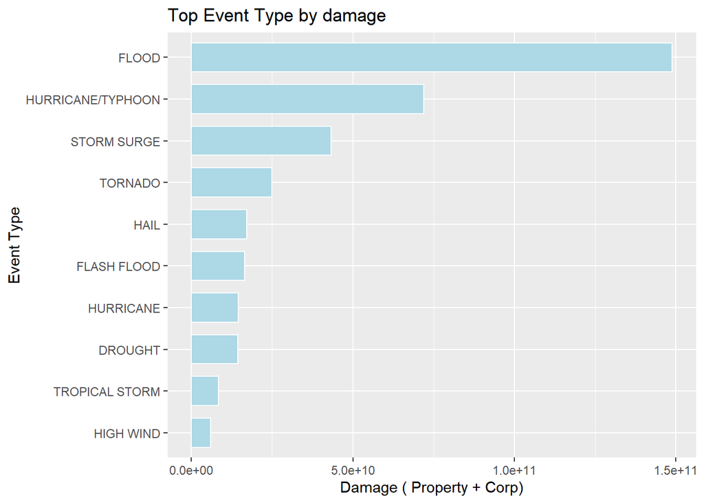

```r
ggplot(topEVdmg, aes(x = reorder(EVTYPE, DMG), y = DMG))+
  geom_bar(stat = 'identity',  color= "white", fill ="lightblue", width = 0.7)+
  labs(title = "Top Event Type by damage", y = "Damage ( Property + Corp)", x = "Event Type")+
  coord_flip()
```

2. Rank the top 10 Event type which impacted health including Fatalities and Injuries.

```r
topEVhealth <- EVhealth[order(EVhealth$healthImpact, decreasing = TRUE), ][1:10, ]
topEVhealth
```

```
## # A tibble: 10 x 2
##    EVTYPE            healthImpact
##    <chr>                    <dbl>
##  1 TORNADO                  22178
##  2 EXCESSIVE HEAT            8188
##  3 FLOOD                     7172
##  4 LIGHTNING                 4792
##  5 TSTM WIND                 3870
##  6 FLASH FLOOD               2561
##  7 THUNDERSTORM WIND         1530
##  8 WINTER STORM              1483
##  9 HEAT                      1459
## 10 HURRICANE/TYPHOON         1339
```

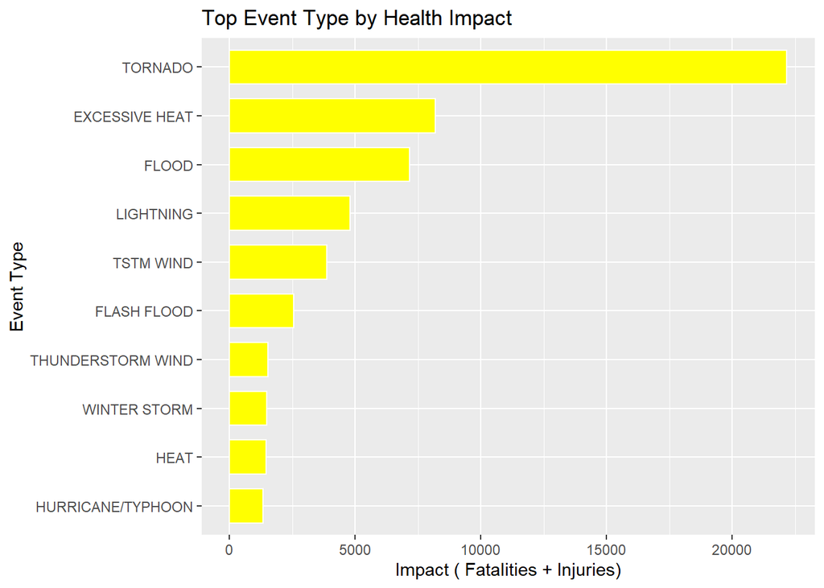

```r
ggplot(topEVhealth, aes(x = reorder(EVTYPE, healthImpact), y = healthImpact))+
  geom_bar(stat = 'identity',  color= "white", fill ="yellow", width = 0.7)+
  labs(title = "Top Event Type by Health Impact", y = "Impact ( Fatalities + Injuries)", x = "Event Type")+
  coord_flip()
```